# Car Speed Presentation

Vasco Pereira

9/15/2020

# Abstract

Drivers that circulate inside cities in Portugal have a maximum speed limit of 50 km/h, but the behaviour is not always in compliance with the law. After observing the possibility of high speeds in the road *Avenida Almirante Gago Coutinho* in *Mem-Martins*, *Sintra*, *Portugal*, the vehicle speed was measured with a **Raspberry Pi Zero W** and an exploratory data analysis was performed in **R**. It was verified that the vehicles moving from *Mem-Martins* to *Sintra* had a mean speed of **69 km/h** and from *Sintra* to *Mem-Martins* had a mean speed of **87 km/h** This road have a pedestrian crossing about 40 meters after the experimental measuring local, and two schools and a sports hall nearby that encourage the presence of many pedestrians in the sidewalk of this road.

**About**

To know more about this project in the original repo [carspeed](https://github.com/VascoRibeiroPereira/carspeed.py)

# Data

Data after cleaning:

```r
str(myData)
```

```
## Classes 'tbl_df', 'tbl' and 'data.frame':    1155 obs. of  3 variables:
##  $ Data      : POSIXct, format: "2020-08-03 10:00:00" "2020-08-03 10:00:00" ...
##  $ Direção   : Factor w/ 2 levels "MemMartins-Sintra",..: 2 1 2 1 2 1 2 1 2 1 ...
##  $ Velocidade: num  88.1 70 88.1 66.3 84.4 ...
```

```r
summary(myData)
```

```
##       Data                                  Direção      Velocidade
##  Min.   :2020-08-03 10:00:00   MemMartins-Sintra:531   Min.   : 39.60
##  1st Qu.:2020-08-12 01:30:00   Sintra-MemMartins:624   1st Qu.: 68.24
##  Median :2020-08-18 18:00:00                           Median : 79.79
##  Mean   :2020-08-18 14:10:51                           Mean   : 78.81
##  3rd Qu.:2020-08-25 12:30:00                           3rd Qu.: 87.87
##  Max.   :2020-09-01 01:00:00                           Max.   :117.00
```

# Data Plot

This is the seen data in the ShinyApp

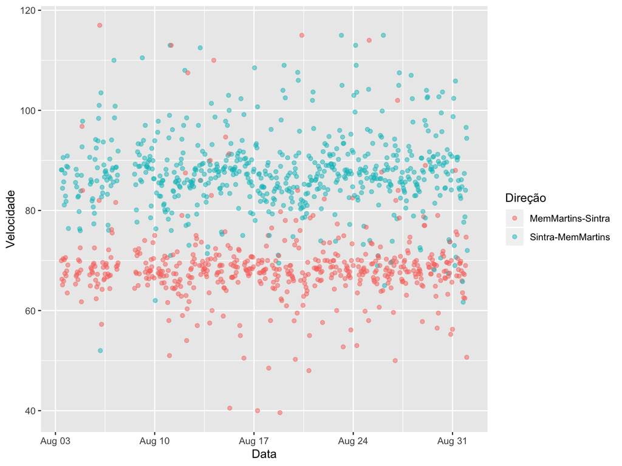

# Conclusion

The possibility of high speeds in the road *Avenida Almirante Gago Coutinho* was confirmed with maximum speeds of **117 km/h** which is a crime in this location.  
The mean speed can be verified in the ShinyApp in both directions.

The velocity is above the permitted values - **69 km/h** and **87 km/h**.  
It is highly recommended the imposition of preventive measures such as speed bumps.